# Housing Rental Policies and Rent Growth Trends in the Chicago Metropolitan Area

Author

YC Zhang

Published

March 10, 2026

## 1. Introduction

Housing affordability has become one of the most pressing urban policy challenges in American cities. In Chicago — the third-largest metropolitan area in the United States — renters face a dual pressure: nominal rents have risen sharply since 2015, while income growth has not kept pace for a large share of households. This mismatch produces *cost burden*, defined as spending more than 30% of gross household income on housing, a threshold long used by the U.S. Department of Housing and Urban Development (HUD) as an affordability benchmark.

This project uses two publicly available datasets to examine three research questions:

1. **Temporal dynamics**: How have rents evolved across Chicago ZIP codes from 2015 to 2026, and how did macro shocks — the COVID-19 pandemic and its associated eviction moratorium — shape that trajectory?
2. **Spatial inequality**: Which Cook County census tracts bear the highest rent burdens, and is geographic clustering visible?
3. **Policy relevance**: Do observable rent trends and burden concentrations align with the reach of key Chicago housing policies?

## 2. Data

### 2.1 American Community Survey (ACS) — Census Tract Level

The primary cross-sectional dataset comes from the U.S. Census Bureau’s 2024 5-Year American Community Survey (ACS). Three tables are used:

| ACS Table | Variable | Unit |
| --- | --- | --- |
| B25064 | Median gross rent | Census tract |
| B19013 | Median household income | Census tract |
| B25070 | Gross rent as % of household income (burden bins) | Census tract |

All three tables cover **Cook County, Illinois**, which contains Chicago and its inner suburbs. After merging and cleaning (dropping tracts with suppressed estimates), the final dataset contains **1,254 census tracts**.

```python
import pandas as pd

acs = pd.read_csv("data/derived-data/acs_clean.csv")
print(f"Tracts: {len(acs):,}")
acs[["tract", "county", "median_rent", "median_income",
     "rent_to_income", "pct_burdened"]].head(8)
```

```
Tracts: 1,254
```

|  | tract | county | median_rent | median_income | rent_to_income | pct_burdened |
| --- | --- | --- | --- | --- | --- | --- |
| 0 | 101.00 | Cook County | 1168.0 | 74145.0 | 18.9 | 48.9 |
| 1 | 102.01 | Cook County | 1378.0 | 63056.0 | 26.2 | 42.9 |
| 2 | 102.02 | Cook County | 1323.0 | 53220.0 | 29.8 | 59.5 |
| 3 | 103.00 | Cook County | 1431.0 | 73105.0 | 23.5 | 44.2 |
| 4 | 104.00 | Cook County | 1347.0 | 54083.0 | 29.9 | 51.4 |
| 5 | 105.01 | Cook County | 1195.0 | 48833.0 | 29.4 | 53.3 |
| 6 | 105.02 | Cook County | 1383.0 | 63125.0 | 26.3 | 54.2 |
| 7 | 105.03 | Cook County | 1273.0 | 32443.0 | 47.1 | 49.6 |

Key summary statistics:

```python
summary = acs[["median_rent", "median_income", "rent_to_income", "pct_burdened"]].describe().T
summary.columns = ["Count","Mean","Std","Min","25%","50%","75%","Max"]
summary = summary.round(1)
summary.index = ["Median Monthly Rent ($)", "Median Household Income ($)",
                 "Rent-to-Income Ratio (%)", "% Renters Cost-Burdened"]
summary
```

|  | Count | Mean | Std | Min | 25% | 50% | 75% | Max |
| --- | --- | --- | --- | --- | --- | --- | --- | --- |
| Median Monthly Rent ($) | 1254.0 | 1494.9 | 467.7 | 347.0 | 1185.2 | 1390.5 | 1717.5 | 3500.0 |
| Median Household Income ($) | 1254.0 | 85674.5 | 40204.6 | 13585.0 | 57361.2 | 78687.5 | 104961.0 | 249531.0 |
| Rent-to-Income Ratio (%) | 1254.0 | 23.8 | 9.2 | 5.5 | 17.8 | 21.9 | 27.4 | 108.5 |
| % Renters Cost-Burdened | 1254.0 | 46.4 | 16.9 | 0.0 | 34.6 | 46.1 | 57.1 | 100.0 |

### 2.2 Zillow Observed Rent Index (ZORI) — ZIP Code Level

The longitudinal dataset is Zillow’s Observed Rent Index (ZORI), a smoothed, seasonally adjusted measure of typical asking rents for single-family homes and condominiums. The raw file contains monthly observations for thousands of U.S. ZIP codes; this analysis filters to the **Chicago-Naperville-Elgin, IL-IN-WI** Core-Based Statistical Area, yielding **206 ZIP codes** with observations spanning **January 2015 through January 2026**.

```python
zillow = pd.read_csv("data/derived-data/zillow_clean.csv")
zillow["date"] = pd.to_datetime(zillow["date"])
print(f"ZIP codes: {zillow['zip_code'].nunique()}  |  "
      f"Date range: {zillow['date'].min().date()} – {zillow['date'].max().date()}  |  "
      f"Rows: {len(zillow):,}")
zillow[["zip_code","city","county","date","zori"]].head(6)
```

```
ZIP codes: 206  |  Date range: 2015-01-31 – 2026-01-31  |  Rows: 9,745
```

|  | zip_code | city | county | date | zori |
| --- | --- | --- | --- | --- | --- |
| 0 | 46304 | Chesterton | Porter County | 2026-01-31 | 1425.000000 |
| 1 | 46307 | Crown Point | Lake County | 2024-01-31 | 1600.368423 |
| 2 | 46307 | Crown Point | Lake County | 2024-02-29 | 1627.205847 |
| 3 | 46307 | Crown Point | Lake County | 2024-03-31 | 1623.777285 |
| 4 | 46307 | Crown Point | Lake County | 2024-04-30 | 1635.703866 |
| 5 | 46307 | Crown Point | Lake County | 2024-05-31 | 1617.062327 |

## 3. Results

### 3.1 Temporal Rent Trends by ZIP Code

The figure below plots the monthly ZORI for a representative sample of 15 Chicago ZIP codes, grouped into low-, mid-, and high-rent tiers based on their time-average rent level. Two policy events are marked with vertical reference lines.

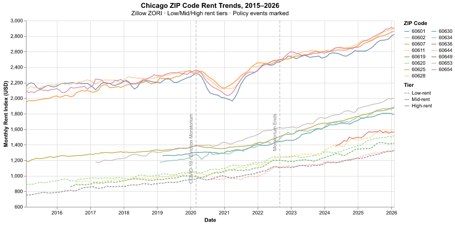

```python
import altair as alt

df_ts = zillow[zillow["city"] == "Chicago"].copy()
df_ts["zip_code"] = df_ts["zip_code"].astype(str)

annual_avg = df_ts.groupby("zip_code")["zori"].mean().reset_index().sort_values("zori")
low  = annual_avg.head(5)["zip_code"].tolist()
n    = len(annual_avg)
mid  = annual_avg.iloc[n//2-2 : n//2+3]["zip_code"].tolist()
high = annual_avg.tail(5)["zip_code"].tolist()
selected = low + mid + high

plot_df = df_ts[df_ts["zip_code"].isin(selected)].copy()

def tier(z):
    if z in low:  return "Low-rent"
    if z in high: return "High-rent"
    return "Mid-rent"
plot_df["tier"] = plot_df["zip_code"].apply(tier)

policy_events = pd.DataFrame([
    {"date": pd.Timestamp("2020-03-01"), "event": "COVID-19 / Eviction Moratorium"},
    {"date": pd.Timestamp("2022-09-01"), "event": "Moratorium Ends"},
])

line = alt.Chart(plot_df).mark_line(opacity=0.8, strokeWidth=1.6).encode(
    x=alt.X("date:T", title="Date"),
    y=alt.Y("zori:Q", title="Monthly Rent Index (USD)",
            scale=alt.Scale(zero=False)),
    color=alt.Color("zip_code:N",
        scale=alt.Scale(scheme="tableau20"),
        legend=alt.Legend(title="ZIP Code", columns=2)),
    strokeDash=alt.StrokeDash("tier:N",
        scale=alt.Scale(domain=["Low-rent","Mid-rent","High-rent"],
                        range=[[4,2],[1,0],[1,0]]),
        legend=alt.Legend(title="Tier")),
    tooltip=["zip_code:N","tier:N",
             alt.Tooltip("date:T", title="Date"),
             alt.Tooltip("zori:Q", format="$,.0f", title="ZORI")]
)
rules = alt.Chart(policy_events).mark_rule(
    color="gray", strokeDash=[6,3], opacity=0.65
).encode(x="date:T")
labels = alt.Chart(policy_events).mark_text(
    angle=270, align="right", baseline="bottom",
    dy=-5, fontSize=10, color="gray"
).encode(x="date:T", text="event:N")

import os
from IPython.display import Image
os.makedirs("figures", exist_ok=True)

ts_chart = (line + rules + labels).properties(
    title=alt.TitleParams(
        "Chicago ZIP Code Rent Trends, 2015–2026",
        subtitle="Zillow ZORI · Low/Mid/High rent tiers · Policy events marked",
        fontSize=14
    ),
    width=750, height=380
)
ts_chart.save("figures/ts_chart.png")
Image("figures/ts_chart.png")
```

**Key findings:**

- **Sustained growth (2015–2019):** Average ZORI across Chicago ZIP codes rose from **$1,493** (Jan 2015) to **$1,541** (2019 average) — a modest 3.2% gain over four years, reflecting broadly stable conditions.
- **COVID-19 disruption (2020–2021):** Rents dipped slightly in 2020–2021 (avg $1,532 → $1,521), consistent with pandemic-era demand shocks (remote work, population movement). The eviction moratorium kept many tenants housed but suppressed market rents temporarily.
- **Post-moratorium surge (2022–2024):** Once the moratorium ended (September 2022), rents accelerated sharply. The 2023 average reached **$1,728** — a **12.1% increase** over 2019. By 2024, the average hit **$1,820**, representing a **+21.9% cumulative gain** since 2015.
- **Tier divergence:** High-rent ZIP codes (North Side, Near North) grew both faster in absolute terms and recovered more quickly post-COVID than low-rent ZIP codes on the South and West sides, widening the intra-city rent gap.

### 3.2 Spatial Distribution: Choropleth Maps

The two maps below show, at the census tract level, (left) median gross monthly rent and (right) the share of renters who are cost-burdened (paying >30% of income on rent).

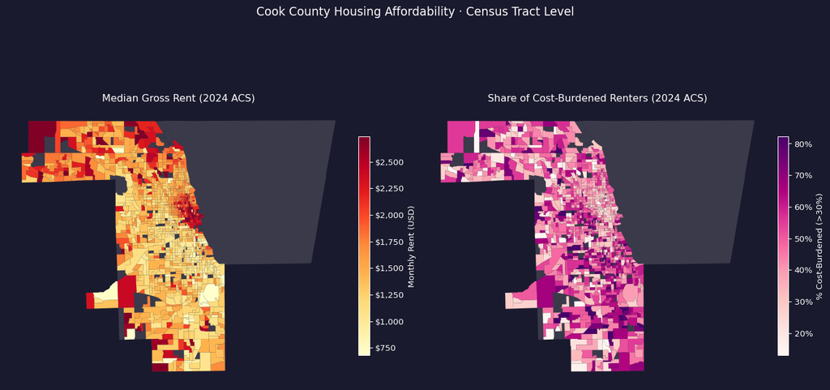

```python
import geopandas as gpd
import matplotlib.pyplot as plt
import matplotlib.colors as mcolors
import matplotlib.ticker as mticker

gdf  = gpd.read_file("data/raw-data/tiger_tract/tl_2024_17_tract.shp")
cook = gdf[gdf["COUNTYFP"] == "031"].copy()
cook["geo_id"] = "1400000US" + cook["GEOID"]
cook = cook.to_crs(epsg=3435)
cook = cook.merge(
    acs[["geo_id","median_rent","pct_burdened"]],
    on="geo_id", how="left"
)

fig, axes = plt.subplots(1, 2, figsize=(14, 8))
fig.patch.set_facecolor("#1a1a2e")

def choropleth(ax, col, title, cbar_label, cmap, fmt_fn):
    data   = cook.dropna(subset=[col])
    nodata = cook[cook[col].isna()]
    vmin, vmax = data[col].quantile(0.02), data[col].quantile(0.98)
    nodata.plot(ax=ax, color="#3a3a4a", linewidth=0)
    data.plot(ax=ax, column=col, cmap=cmap,
              vmin=vmin, vmax=vmax,
              linewidth=0.05, edgecolor="#888", legend=False)
    sm = plt.cm.ScalarMappable(cmap=cmap,
                               norm=mcolors.Normalize(vmin=vmin, vmax=vmax))
    sm.set_array([])
    cb = fig.colorbar(sm, ax=ax, fraction=0.03, pad=0.02, shrink=0.72)
    cb.set_label(cbar_label, color="white", fontsize=10)
    cb.ax.yaxis.set_tick_params(color="white")
    cb.outline.set_edgecolor("white")
    plt.setp(cb.ax.yaxis.get_ticklabels(), color="white")
    cb.ax.yaxis.set_major_formatter(mticker.FuncFormatter(fmt_fn))
    ax.set_facecolor("#1a1a2e")
    ax.set_title(title, color="white", fontsize=12, pad=8)
    ax.axis("off")

choropleth(axes[0], "median_rent",
           "Median Gross Rent (2024 ACS)",
           "Monthly Rent (USD)", "YlOrRd",
           lambda x, _: f"${x:,.0f}")

choropleth(axes[1], "pct_burdened",
           "Share of Cost-Burdened Renters (2024 ACS)",
           "% Cost-Burdened (>30%)", "RdPu",
           lambda x, _: f"{x:.0f}%")

fig.suptitle("Cook County Housing Affordability · Census Tract Level",
             color="white", fontsize=14, y=0.98)
plt.tight_layout()
plt.savefig("choropleth_preview.png", dpi=130,
            bbox_inches="tight", facecolor=fig.get_facecolor())
plt.show()
```

**Key findings:**

- **North-South rent gradient:** The highest-rent tracts cluster in the Near North Side, Lincoln Park, and Lakeview neighborhoods. Median rents in these tracts frequently exceed $2,000/month. The South Side and parts of the West Side show substantially lower median rents — some tracts below $900/month.
- **Burden does not mirror rent:** Cost burden is highest not in the most expensive tracts, but in low-to-moderate rent areas where incomes are also low. **83.4%** of Cook County tracts have more than 30% of their renters cost-burdened; **40.7%** exceed the 50% threshold — meaning in nearly half of all tracts, the *majority* of renters are spending more than 30% of income on housing.
- **Geographic clustering:** Severe burden concentrates in a contiguous band of South and West Side tracts (Englewood, Garfield Park, Austin, Roseland), consistent with historical patterns of disinvestment and lower household incomes.

### 3.3 Affordability Distribution

[figure not shown]

```python
df_rti = acs[acs["rent_to_income"] <= 100].copy()
df_rti["burden_group"] = pd.cut(
    df_rti["pct_burdened"],
    bins=[0, 30, 50, 70, 101],
    labels=["Low (<30%)", "Moderate (30–50%)", "High (50–70%)", "Severe (>70%)"]
)

hist = alt.Chart(df_rti).mark_bar(opacity=0.8).encode(
    x=alt.X("rent_to_income:Q", bin=alt.Bin(maxbins=48),
            title="Annual Rent-to-Income Ratio (%)"),
    y=alt.Y("count():Q", title="Number of Census Tracts"),
    color=alt.Color("burden_group:N",
        scale=alt.Scale(
            domain=["Low (<30%)","Moderate (30–50%)","High (50–70%)","Severe (>70%)"],
            range=["#4daf4a","#ff7f00","#e41a1c","#984ea3"]
        ),
        legend=alt.Legend(title="Cost-Burden Rate", orient="top-right")
    ),
    tooltip=["burden_group:N", alt.Tooltip("count():Q", title="Tracts")]
)
rule30 = alt.Chart(pd.DataFrame({"x":[30]})).mark_rule(
    color="white", strokeDash=[5,3], opacity=0.7
).encode(x="x:Q")
lbl30 = alt.Chart(pd.DataFrame({"x":[30],"t":["← HUD 30% threshold"]})).mark_text(
    align="left", dx=4, dy=-120, color="white", fontSize=10
).encode(x="x:Q", text="t:N")

# ECDF
df_ecdf = acs.dropna(subset=["pct_burdened"]).sort_values("pct_burdened").reset_index(drop=True)
df_ecdf["ecdf"] = (df_ecdf.index + 1) / len(df_ecdf) * 100

area = alt.Chart(df_ecdf).mark_area(
    line={"color":"#e45756","strokeWidth":2},
    color=alt.Gradient(
        gradient="linear",
        stops=[alt.GradientStop(color="#e4575650", offset=0),
               alt.GradientStop(color="#e4575600", offset=1)],
        x1=1, x2=1, y1=1, y2=0
    )
).encode(
    x=alt.X("pct_burdened:Q", title="% Renters Cost-Burdened"),
    y=alt.Y("ecdf:Q", title="Cumulative % of Tracts"),
    tooltip=[
        alt.Tooltip("pct_burdened:Q", format=".1f", title="% Burdened"),
        alt.Tooltip("ecdf:Q", format=".1f", title="Cumulative Tracts %")
    ]
)
ref = alt.Chart(pd.DataFrame({"y":[50]})).mark_rule(
    color="gray", strokeDash=[4,3], opacity=0.6
).encode(y="y:Q")
ref_lbl = alt.Chart(pd.DataFrame({"y":[50],"x":[95],"t":["Median tract"]})).mark_text(
    align="right", color="gray", fontSize=10
).encode(x="x:Q", y="y:Q", text="t:N")

chart_hist = (hist + rule30 + lbl30).properties(
    width=380, height=300,
    title=alt.TitleParams("Rent-to-Income Ratio Distribution",
                          subtitle="Colored by cost-burden rate", fontSize=13)
)
chart_ecdf = (area + ref + ref_lbl).properties(
    width=380, height=300,
    title=alt.TitleParams("Cumulative Distribution: Cost-Burden Rate",
                          subtitle="Share of tracts with ≤ X% of renters cost-burdened",
                          fontSize=13)
)

dist_chart = alt.hconcat(chart_hist, chart_ecdf).resolve_scale(color="independent")
dist_chart.save("figures/dist_chart.png")
Image("figures/dist_chart.png")
```

[output not shown]

## 4. Interactive Dashboard

An interactive Streamlit dashboard supplements the static analysis above with dynamic filtering by city, ZIP code, year range, and variable selection.

**Dashboard URL:** https://datavisualizationfinalproject-m7rnhvqfe9uemeai2vqwjt.streamlit.app/

> Note: Streamlit apps may need to be “woken up” if they have not been accessed in the last 24 hours.

The app provides three tabs:

- **Rent Trends Over Time** — multi-select ZIP code filter, year range slider, and optional policy event overlay
- **Choropleth Map** — switchable variable (rent / RTI / burden rate) and color scheme
- **Affordability Distribution** — interactive histogram, ECDF, and rent-vs-burden scatter plot

## 5. Policy Discussion

### 5.1 The Eviction Moratorium and Post-Pandemic Rent Acceleration

The post-moratorium surge was not uniform. High-rent North Side ZIP codes recovered faster and peaked higher, while low-rent South Side ZIP codes showed smaller absolute gains but larger proportional income-to-rent deterioration, because starting incomes were already low.

### 5.2 Geographic Concentration and the Limits of Market Solutions

The choropleth maps reveal a persistent spatial pattern: severe cost burden is geographically concentrated in a contiguous corridor of South and West Side neighborhoods. These are the same areas that have historically faced **redlining, disinvestment**, and limited access to subsidized housing. High burden in low-rent tracts indicates that rents, even when nominally affordable, outpace incomes — a dynamic that market-rate construction (typically built in high-rent areas) does not directly address.

### 5.3 Policy Implications

| Observation | Policy implication |
| --- | --- |
| Post-moratorium rent spike | Strengthen tenant relocation assistance and just-cause eviction protections |
| Severe burden concentrated in South/West | Target voucher distribution and affordable unit production to high-burden corridors |
| 83% of tracts exceed HUD 30% threshold | Expand income-based rental assistance eligibility; current programs are insufficient in scale |
| Intra-city tier divergence | Anti-displacement zoning overlays in rapidly appreciating North Side tracts |

Chicago’s existing Affordable Requirements Ordinance (ARO) mandates that large residential developments include a share of affordable units, but the income thresholds and enforcement mechanisms have been criticized as inadequate. The concentration of burden shown in this analysis supports advocates’ calls for a strengthened ARO with higher affordable shares and deeper income targeting.

## 6. Conclusion

This analysis documents three interconnected patterns in Chicago’s rental market:

1. **Rents rose 21.9% between 2015 and 2024**, with the sharpest acceleration following the end of the COVID-19 eviction moratorium in late 2022.
2. **Geographic inequality is severe and spatially clustered**: the highest-rent areas are on the North Side and downtown, but the highest *burden rates* are concentrated on the South and West sides, where lower incomes make even moderate rents unaffordable.
3. **Burden is the norm, not the exception**: 83% of Cook County census tracts have more than 30% of their renters cost-burdened, and 41% exceed the 50% threshold. This signals a systemic affordability failure rather than an isolated problem.

Together, these findings suggest that Chicago’s housing affordability crisis requires policies that address *both* rent levels and income inadequacy — neither supply expansion alone nor income supports alone will suffice. Spatially targeted interventions in high-burden corridors, stronger tenant protections, and scaled-up rental assistance represent the most evidence-supported near-term policy directions.

## References

- U.S. Census Bureau. (2024). *American Community Survey 5-Year Estimates*, Tables B25064, B19013, B25070. Retrieved from https://data.census.gov
- Zillow Research. (2024). *Zillow Observed Rent Index (ZORI)*. Retrieved from https://www.zillow.com/research/data/
- U.S. Census Bureau. (2024). *TIGER/Line Shapefiles: Census Tracts, Illinois*. Retrieved from https://www.census.gov/geographies/mapping-files/time-series/geo/tiger-line-file.html
- City of Chicago. (2023). *Affordable Requirements Ordinance*. Retrieved from https://www.chicago.gov/city/en/depts/doh/provdrs/developers/svcs/aro.html
- National Low Income Housing Coalition. (2024). *Out of Reach 2024*.